# **Criando um relatório de Análise de Ações no Python**

Autor

Luiz Henrique/Fernando da Silva

Resumo

Neste texto mostramos que dá pra enterrar aquele seu relatório manual no Excel e automatizar toda a rotina de análise de dados usando o Python + Quarto. Mostramos um exemplo de relatório de ações com dados da ITSA4.

A necessidade de criar relatórios para sumarizar e apresentar dados e análises é rotineira para quem trabalha na área de dados. Também é frequente o uso de ferramentas simples do tipo *point & click*, como Excel e Word, para produzir relatórios. Algo mais frequente ainda são problemas de reprodutibilidade e automatização que acabam acontecendo com o uso de tais ferramentas.

Neste texto mostramos uma alternativa interessante para usuários de Python. Imagine escrever seu relatório, analisar e apresentar os dados com código de Python usando apenas uma interface, sem copia e cola e sem quebra galhos? A ferramenta Quarto proporciona exatamente isso, permitindo que o usuário desenvolva seu relatório mesclando texto, imagens, tabelas e códigos em um único documento fonte. No final, o usuário pode compilar o documento e gerar um PDF, um HTML, apresentação de slides, etc.

A seguir demonstramos o fluxo de trabalho de usar o Quarto para produzir um relatório de exemplo com dados econômicos. Para saber mais veja o curso de [**Produção de Relatórios Automáticos usando Python**](https://analisemacro.com.br/curso/producao-de-relatorios-automaticos-usando-python/)**.**

# Ferramentas

Como mencionado, iremos utilizar o software Quarto, que permite criar diversos tipos de documentos. O interessante da ferramenta é a possibilidade integração com as linguagens de programação Python, R, Julia e Observable, bem como a integração com IDEs como Jupyter Notebook, VS Code e Rstudio, facilitando todo o processo de criação dos documentos para o usuário. Neste tutorial abordaremos a criação do documento usando o Python e o VS Code.

Antes de construir a apresentação devemos obter a ferramenta Quarto conforme a IDE utilizada. Você pode realizar o download através do link https://quarto.org/docs/get-started/ e integrar a ferramenta conforme a IDE de interesse em seus respectivos ícones.

[figure not shown]

Para o caso do VS Code que usaremos neste tutorial, o processo pode ser mais simples. Basta buscar o software Quarto na aba de “Extensions” da ferramenta e realizar o download.

[figure not shown]

# Construindo o relatório

### Passo 01: **criar o arquivo do relatório**

Basta abrir o VS Code ou interface de sua preferência e criar um arquivo “.qmd”. Este arquivo se chama Quarto e é a fonte do conteúdo e código que gera o relatório.

Para isso, use a opção “Command Palette” na aba “View” (ctrl + shift + p) e selecione Quarto: New Document.

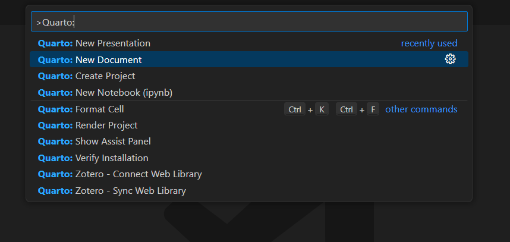

## Passo 02: definir o título e cabeçalho

Utilize os [parâmetros de YAML](https://quarto.org/docs/get-started/hello/vscode.html#yaml-options) para inserir título, subtítulo, autor, data e muito mais no seu relatório. Como exemplo, vamos criar um relatório de ação da ITSA4 e aqui definimos:

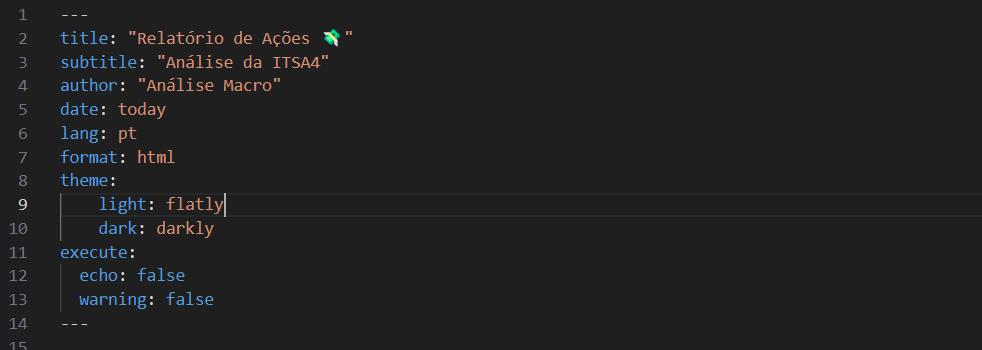

Parâmetros opcionais no cabeçalho do relatório

- Título
- Subtítulo
- Nome do autor
- Data do relatório
- Linguagem utilizada
- Formato de saída do relatório
- Temas padronizados
- Controle de exibição de códigos

## Passo 03: importar os dados

Para importar os dados a serem utilizados no relatório é necessário criar uma célula de código Python e escrever o código adequado de importação de dados, tal como:

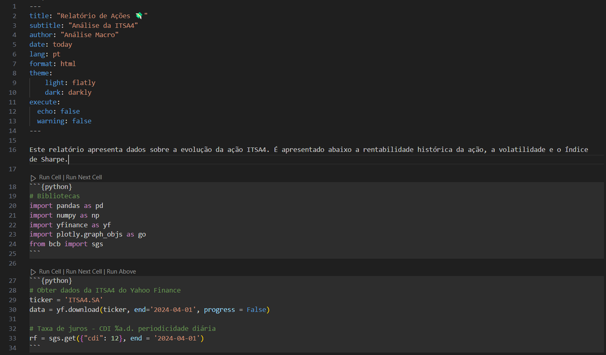

Criando célula de código para importar dados

Ao clicar em “Run Cell” o resultado do código é exibido no próprio VS Code (Python e Quarto devem estar instalados e configurados para isso funcionar).

## Passo 04: criar análises dos dados

Em seguida vamos criar algumas análises simples dos dados para colocar neste relatório de exemplo:

1. Uma gráfico de rentabilidade acumulada;
2. Uma tabela com a rentabilidade histórica
3. Índices de Risco-Retorno

A análise criada de exemplo para este exercício pode ser acessada através do arquivo relatorio.qmd, e o usuário poderá replicar os códigos conforme o documento.

## Passo 05: compilar o relatório

Uma vez que o relatório está produzido, basta compilá-lo para gerar o arquivo final (HTML ou outro definido no início). Para isso é necessário acessar através do terminal (atalho `Ctrl + '`) a pasta onde o relatório está localizado e executar o comando de renderização, conforme abaixo:

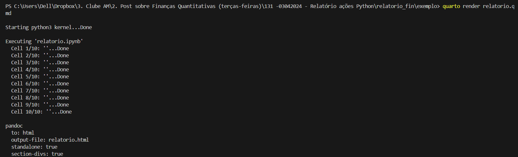

Compilando relatório com comando no terminal

O nome do arquivo final salvo na mesma pasta é “relatorio.html”, que você pode abrir em qualquer navegador de internet para ver o resultado:

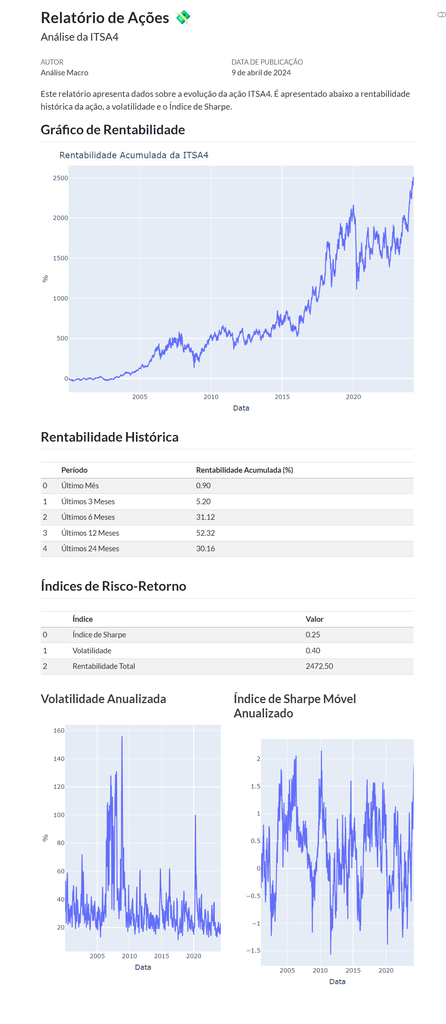

Este relatório é bem simples e básico, serve apenas para demonstrar o fluxo de trabalho com o Quarto + Python. Dá para criar relatórios mais completos, complexos e personalizados. Para saber mais veja o curso de [**Produção de Relatórios Automáticos usando Python**](https://analisemacro.com.br/curso/producao-de-relatorios-automaticos-usando-python/)**.**